# Classifying SPAM Email using BERT

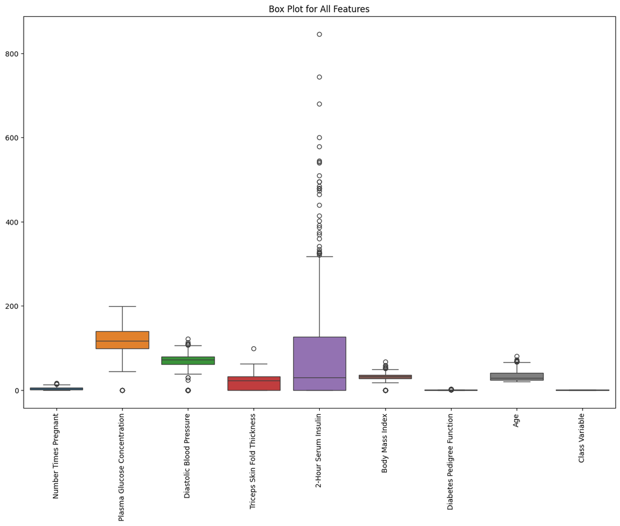

```python
# Box Plots
  plt.figure(figsize=(15, 10))
  sns.boxplot(data=datasetpd)
  plt.xticks(rotation=90)
  plt.title('Box Plot for All Features')
  plt.show()
```

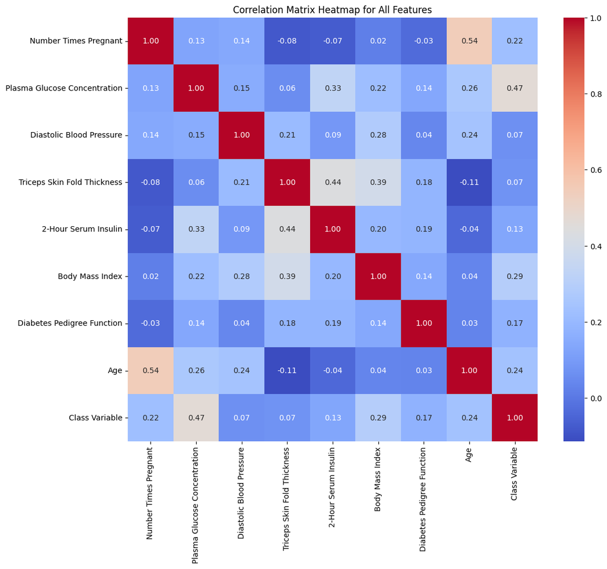

```python
# Correlation Matrix with Heatmap
  plt.figure(figsize=(12, 10))
  sns.heatmap(datasetpd.corr(), annot=True, cmap='coolwarm', fmt=".2f")
  plt.title('Correlation Matrix Heatmap for All Features')
  plt.show()
```

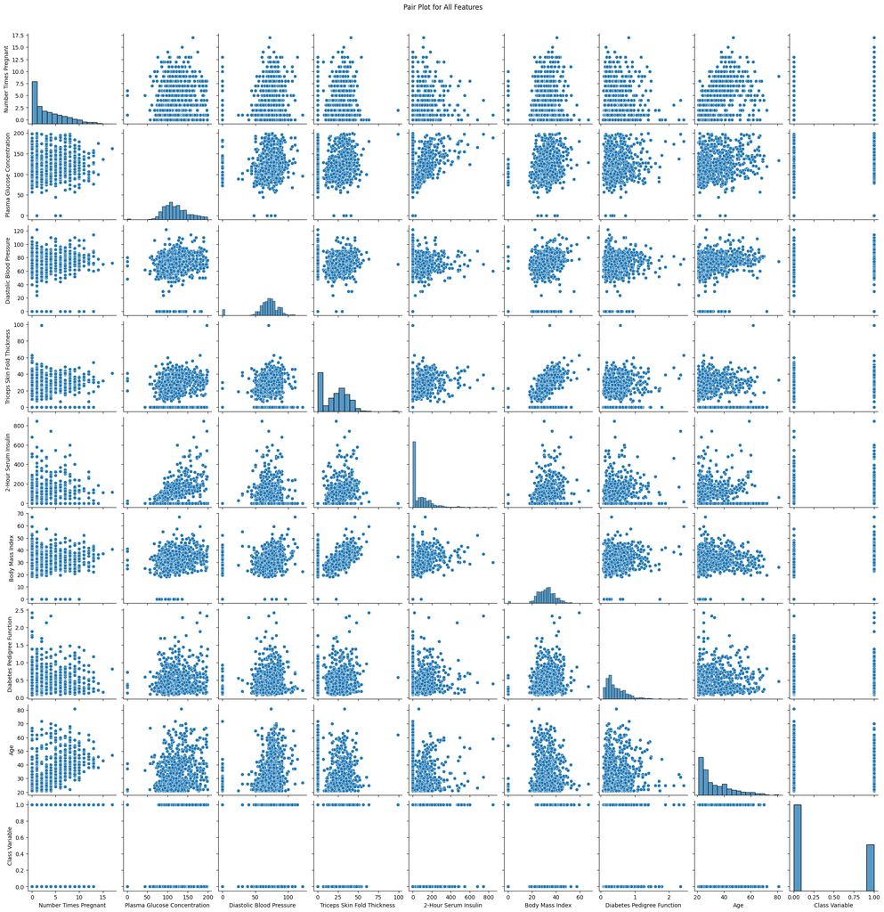

```python
# Pair Plot
  sns.pairplot(datasetpd)
  plt.suptitle('Pair Plot for All Features', y=1.02)
  plt.show()
```

Notice:

- No Null values
- There are some features that have values that are very large when compared to other features. For example, Body mass is very small compared to Plasma. We should standardize the data.

```python
dataset
```

```
array([[  6.   , 148.   ,  72.   , ...,   0.627,  50.   ,   1.   ],
         [  1.   ,  85.   ,  66.   , ...,   0.351,  31.   ,   0.   ],
         [  8.   , 183.   ,  64.   , ...,   0.672,  32.   ,   1.   ],
         ...,
         [  5.   , 121.   ,  72.   , ...,   0.245,  30.   ,   0.   ],
         [  1.   , 126.   ,  60.   , ...,   0.349,  47.   ,   1.   ],
         [  1.   ,  93.   ,  70.   , ...,   0.315,  23.   ,   0.   ]])
```

```python
# Compute summary statistics
  summary_stats = datasetpd.describe()

  # Display the summary statistics
  print("Summary Statistics:")
  print(summary_stats)
```

```
Summary Statistics:
         Number Times Pregnant  Plasma Glucose Concentration  \
  count             768.000000                    768.000000
  mean                3.845052                    120.894531
  std                 3.369578                     31.972618
  min                 0.000000                      0.000000
  25%                 1.000000                     99.000000
  50%                 3.000000                    117.000000
  75%                 6.000000                    140.250000
  max                17.000000                    199.000000

         Diastolic Blood Pressure  Triceps Skin Fold Thickness  \
  count                768.000000                   768.000000
  mean                  69.105469                    20.536458
  std                   19.355807                    15.952218
  min                    0.000000                     0.000000
  25%                   62.000000                     0.000000
  50%                   72.000000                    23.000000
  75%                   80.000000                    32.000000
  max                  122.000000                    99.000000

         2-Hour Serum Insulin  Body Mass Index  Diabetes Pedigree Function  \
  count            768.000000       768.000000                  768.000000
  mean              79.799479        31.992578                    0.471876
  std              115.244002         7.884160                    0.331329
  min                0.000000         0.000000                    0.078000
  25%                0.000000        27.300000                    0.243750
  50%               30.500000        32.000000                    0.372500
  75%              127.250000        36.600000                    0.626250
  max              846.000000        67.100000                    2.420000

                Age  Class Variable
  count  768.000000      768.000000
  mean    33.240885        0.348958
  std     11.760232        0.476951
  min     21.000000        0.000000
  25%     24.000000        0.000000
  50%     29.000000        0.000000
  75%     41.000000        1.000000
  max     81.000000        1.000000
```

```python
#Defining the Keras model

  #Standardize the dataset
  X=dataset[:,0:8]
  y=dataset[:,8]

  #standardize the dataset
  scaler = StandardScaler()
  X = scaler.fit_transform(X)

  #First create an empty ANN
  classifier = Sequential()

  # Add input layer and first hidden layer with BatchNormalization and Dropout
  classifier.add(Dense(units=64, kernel_initializer="he_uniform", input_dim=8, activation='relu'))
  classifier.add(BatchNormalization())
  classifier.add(Dropout(0.5))

  # Add additional hidden layers with BatchNormalization and Dropout
  classifier.add(Dense(units=64, kernel_initializer="he_uniform", activation='relu'))
  classifier.add(BatchNormalization())
  classifier.add(Dropout(0.5))

  classifier.add(Dense(units=64, kernel_initializer="he_uniform", activation='relu'))
  classifier.add(BatchNormalization())
  classifier.add(Dropout(0.5))

  #output layer
  #Activation Function: SIGMOID (Classification Problem)
  #output_dim = 1
  #Weight Initialization Function: Xavier-Glorot
  classifier.add(Dense(units=1,kernel_initializer="glorot_uniform",activation='sigmoid'))
```

```python
#Compile the Keras model
  classifier.compile(loss='binary_crossentropy',optimizer='adam',metrics=['accuracy'])

  #Fit the Keras model on dataset
  classifier.fit(X,y,epochs=100,batch_size=10,verbose=1)

  #Define early stopping
  early_stopping = EarlyStopping(monitor='val_loss', mode='min', verbose=1, patience=10)

  # Fit the Keras model on the dataset with a validation split
  history = classifier.fit(X, y, epochs=100, batch_size=32, verbose=1, validation_split=0.2, callbacks=[early_stopping])

  #Make predictions with the model
  predictions = (classifier.predict(X) > 0.5).astype(int)

  #Summarize the first 5 cases
  for i in range(50):
    print('%s => %d (expected %d)' % (X[i].tolist(), predictions[i], y[i]))

  #rounded=[round(x[0])for x in predictions]
  #print(rounded)

  scores = classifier.evaluate(X,y)
  print("\n%s: %.2f%%" % (classifier.metrics_names[1], scores[1]*100))
```

```
  Epoch 22: early stopping
  [0.6399472601593618, 0.8483237946271883, 0.149640752628208, 0.9072699252723591, -0.6928905722954664, 0.20401277134626386, 0.4684919773786552, 1.4259954044228451] => 1 (expected 1)
  [-0.8448850534430246, -1.1233963609784168, -0.16054574674686284, 0.5309015587207719, -0.6928905722954664, -0.6844219461567719, -0.36506077757159777, -0.19067190513648619] => 0 (expected 0)
  [1.233880185600316, 1.9437238810747468, -0.2639412465385531, -1.2882122129452327, -0.6928905722954664, -1.1032554558367744, 0.6043973178596749, -0.10558415200178453] => 1 (expected 1)
  [-0.8448850534430246, -0.9982077796701243, -0.16054574674686284, 0.15453319216918474, 0.12330164444496873, -0.49404307812040704, -0.9207626142050997, -1.0415494364835027] => 0 (expected 0)
  [-1.141851516163502, 0.5040551960293843, -1.5046872440388366, 0.9072699252723591, 0.7658359427299921, 1.4097456022432409, 5.484909100466952, -0.02049639886708288] => 1 (expected 1)
  [0.3429807974388845, -0.15318485583915073, 0.2530362524198983, -1.2882122129452327, -0.6928905722954664, -0.8113411915143484, -0.818078579174996, -0.2757596582711878] => 0 (expected 0)
  [-0.25095212800207, -1.3424763782679283, -0.9877097450803851, 0.7190857419965655, 0.0712042689083452, -0.12597726658343528, -0.6761330013392646, -0.6161106708099945] => 0 (expected 1)
  [1.8278131110412708, -0.18448200116622385, -3.572597239872642, -1.2882122129452327, -0.6928905722954664, 0.4197754884541434, -1.0204265305578473, -0.3608474114058895] => 1 (expected 0)
  [-0.5479185907225473, 2.38188391565377, 0.046245252836517724, 1.534550536191671, 4.021921913768962, -0.18943688926222355, -0.9479436823013037, 1.6812586638269502] => 1 (expected 1)
  [1.233880185600316, 0.12848945210450713, 1.3903867501284914, -1.2882122129452327, -0.6928905722954664, -4.060473872668307, -0.7244549001769603, 1.7663464169616518] => 0 (expected 1)
  [0.04601433471840724, -0.3409677278015893, 1.183595750545111, -1.2882122129452327, -0.6928905722954664, 0.71168975277657, -0.8482797659485559, -0.2757596582711878] => 0 (expected 0)
  [1.8278131110412708, 1.4742667011686503, 0.2530362524198983, -1.2882122129452327, -0.6928905722954664, 0.7624574509196004, 0.19668129641661633, 0.06459135426761878] => 1 (expected 1)
  [1.8278131110412708, 0.5666494866835304, 0.5632227517949692, -1.2882122129452327, -0.6928905722954664, -0.6209623234779835, 2.9268685807464303, 2.021609676365757] => 1 (expected 0)
  [-0.8448850534430246, 2.1315067530371854, -0.47073224612193365, 0.15453319216918474, 6.65283937836845, -0.240204587405254, -0.2231151997358662, 2.19178518263516] => 1 (expected 1)
  [0.3429807974388845, 1.411672410514504, 0.149640752628208, -0.09637905219854004, 0.8266162141893862, -0.7859573424428331, 0.34768723028441556, 1.511083157557547] => 1 (expected 1)
  [0.9369137228798391, -0.6539391810723203, -3.572597239872642, -1.2882122129452327, -0.6928905722954664, -0.2528965119410118, 0.03661500651674877, -0.10558415200178453] => 0 (expected 1)
  [-1.141851516163502, -0.09059056518500455, 0.7700137513783497, 1.6600066583755335, 1.3041754899417684, 1.7524275647086969, 0.2389629578996002, -0.19067190513648619] => 1 (expected 1)
  [0.9369137228798391, -0.4348591637828086, 0.2530362524198983, -1.2882122129452327, -0.6928905722954664, -0.30366421008404226, -0.6580122892751287, -0.19067190513648619] => 0 (expected 1)
  [-0.8448850534430246, -0.560047745091101, -2.021664742997288, 1.0954541085481526, 0.027789789294492277, 1.4351294513147557, -0.8724407153674039, -0.02049639886708288] => 0 (expected 0)
  [-0.8448850534430246, -0.18448200116622385, 0.046245252836517724, 0.5936296198127031, 0.1406674362905099, 0.33093201670384037, 0.1725203469977684, -0.10558415200178453] => 0 (expected 1)
  [-0.25095212800207, 0.15978659743158022, 0.9768047509617303, 1.2836382918239462, 1.3475899695556213, 0.9274524698844495, 0.7010411155350663, -0.5310229176752927] => 0 (expected 0)
```

[output cut: 29 more lines]

```
  accuracy: 81.38%
```

```python
classifier.summary()
```

```
Model: "sequential_1"
  _________________________________________________________________
   Layer (type)                Output Shape              Param #
  =================================================================
   dense_4 (Dense)             (None, 64)                576

   batch_normalization_3 (Bat  (None, 64)                256
   chNormalization)

   dropout_3 (Dropout)         (None, 64)                0

   dense_5 (Dense)             (None, 64)                4160

   batch_normalization_4 (Bat  (None, 64)                256
   chNormalization)

   dropout_4 (Dropout)         (None, 64)                0

   dense_6 (Dense)             (None, 64)                4160

   batch_normalization_5 (Bat  (None, 64)                256
   chNormalization)

   dropout_5 (Dropout)         (None, 64)                0

   dense_7 (Dense)             (None, 1)                 65

  =================================================================
  Total params: 9729 (38.00 KB)
  Trainable params: 9345 (36.50 KB)
  Non-trainable params: 384 (1.50 KB)
  _________________________________________________________________
```

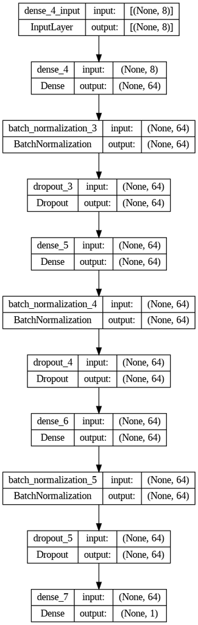

```python
# Visualize the model
  plot_model(classifier, to_file='model_plot.png', show_shapes=True, show_layer_names=True)
```

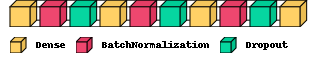

```python
#visualize the model using VisualKeras

  #visualize the CNN architecture using visualkeras
  visualkeras.layered_view(classifier, legend=True)
```

[output not shown]

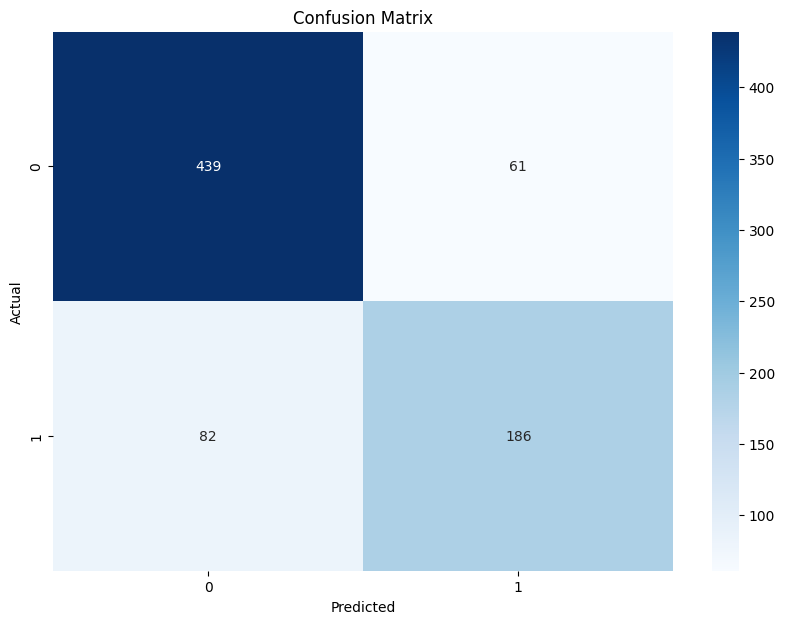

```python
# Evaluate the model
  accuracy = accuracy_score(y, predictions)
  print(f"Accuracy: {accuracy*100:.2f}%")

  #Confusion Matrix
  cm = confusion_matrix(y,predictions)

  # Plot Confusion Matrix
  plt.figure(figsize=(10,7))
  sns.heatmap(cm, annot=True, fmt='d', cmap='Blues')
  plt.xlabel('Predicted')
  plt.ylabel('Actual')
  plt.title('Confusion Matrix')
  plt.show()
```

```python
# Classification Report
  class_report = classification_report(y, predictions, target_names=['Negative', 'Positive'], output_dict=True)

  # Display Summary of Metrics
  print("\nClassification Report:")
  print(f"{'Metric':<20}{'Negative':<15}{'Positive':<15}")
  print(f"{'-'*50}")
  print(f"{'Precision':<20}{class_report['Negative']['precision']:<15.2f}{class_report['Positive']['precision']:<15.2f}")
  print(f"{'Recall':<20}{class_report['Negative']['recall']:<15.2f}{class_report['Positive']['recall']:<15.2f}")
  print(f"{'F1-Score':<20}{class_report['Negative']['f1-score']:<15.2f}{class_report['Positive']['f1-score']:<15.2f}")
  print(f"{'Support':<20}{class_report['Negative']['support']:<15}{class_report['Positive']['support']:<15}")

  # Overall metrics
  print(f"\n{'Overall Accuracy':<20}{accuracy*100:.2f}%")
  print(f"{'Overall Precision':<20}{class_report['macro avg']['precision']*100:.2f}%")
  print(f"{'Overall Recall':<20}{class_report['macro avg']['recall']*100:.2f}%")
  print(f"{'Overall F1-Score':<20}{class_report['macro avg']['f1-score']*100:.2f}%")
```

```
  Classification Report:
  Metric              Negative       Positive
  --------------------------------------------------
  Precision           0.84           0.75
  Recall              0.88           0.69
  F1-Score            0.86           0.72
  Support             500            268

  Overall Accuracy    81.38%
  Overall Precision   79.78%
  Overall Recall      78.60%
  Overall F1-Score    79.11%
```

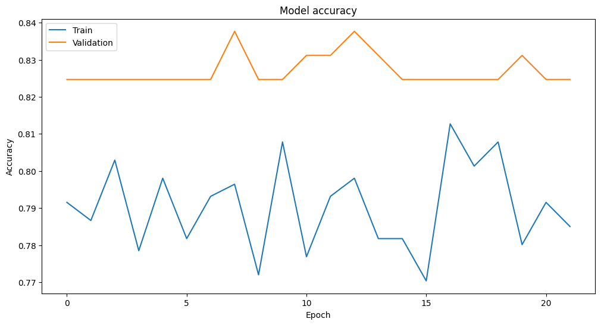

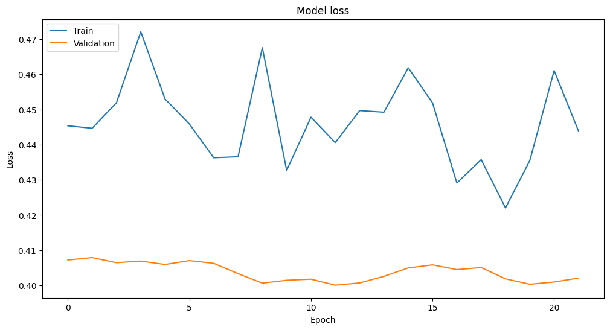

```python
# Plot training & validation accuracy values
  plt.figure(figsize=(12, 6))
  plt.plot(history.history['accuracy'])
  plt.plot(history.history['val_accuracy'])
  plt.title('Model accuracy')
  plt.ylabel('Accuracy')
  plt.xlabel('Epoch')
  plt.legend(['Train', 'Validation'], loc='upper left')
  plt.show()

  # Plot training & validation loss values
  plt.figure(figsize=(12, 6))
  plt.plot(history.history['loss'])
  plt.plot(history.history['val_loss'])
  plt.title('Model loss')
  plt.ylabel('Loss')
  plt.xlabel('Epoch')
  plt.legend(['Train', 'Validation'], loc='upper left')
  plt.show()
```

## Improving Results

We obtained 81.38% efficiency which is a great start but not good enough.

We can try:

- hyperparamter tunning,
- handling imbalanced data (use SMOTE, XGBoost, LightGBM),
- Apply regularization techniques (L1 or L2 to prevent overfitting) and find balance between bias and variance,
- Cross Validation
- Emsemble Learning